# Проект по модулю Продвинутый SQL

## Описание

Проект состоит из двух частей. В самостоятельном проекте вы будете работать с базой данных StackOverflow — сервиса вопросов и ответов о программировании. StackOverflow похож на социальную сеть — пользователи сервиса задают вопросы, отвечают на посты, оставляют комментарии и ставят оценки другим ответам. Вы будете работать с версией базы, где хранятся данные о постах за 2008 год, но в таблицах вы найдёте информацию и о более поздних оценках, которые эти посты получили.

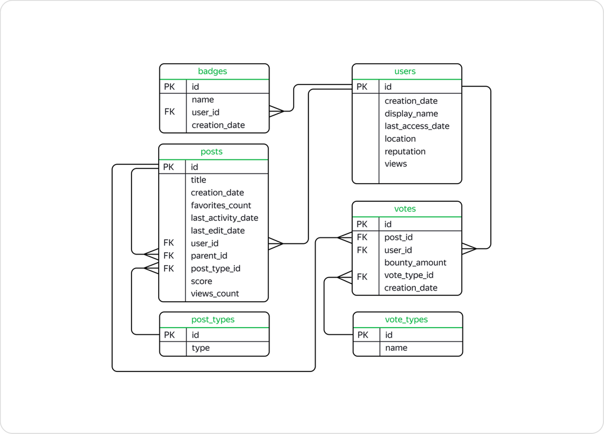

## Первый блок задач

1. Найдите количество вопросов, которые набрали больше 300 очков или как минимум 100 раз были добавлены в «Закладки».

```
SELECT count(*)
FROM stackoverflow.posts AS p
JOIN stackoverflow.post_types AS pt ON p.post_type_id=pt.id
WHERE TYPE = 'Question'
  AND (score > 300
       OR favorites_count >= 100)
```

2. Сколько в среднем в день задавали вопросов с 1 по 18 ноября 2008 включительно? Результат округлите до целого числа.

```
SELECT round(avg(q_count))
FROM
  (SELECT creation_date::date AS date,
          count(*) AS q_count
   FROM stackoverflow.posts AS p
   JOIN stackoverflow.post_types AS pt ON p.post_type_id=pt.id
   WHERE TYPE = 'Question'
     AND creation_date BETWEEN '2008-11-01' AND '2008-11-19'
   GROUP BY date
   ORDER BY date) AS i
```

3. Сколько пользователей получили значки сразу в день регистрации? Выведите количество уникальных пользователей.

```
SELECT count(DISTINCT u.id)
FROM stackoverflow.users AS u
JOIN stackoverflow.badges AS b ON b.user_id=u.id
WHERE b.creation_date::date=u.creation_date::date
```

4. Сколько уникальных постов пользователя с именем Joel Coehoorn получили хотя бы один голос?

```
SELECT count(DISTINCT p.id)
FROM stackoverflow.users AS u
JOIN stackoverflow.posts AS p ON p.user_id=u.id
JOIN stackoverflow.votes AS v ON p.id=v.post_id
WHERE display_name = 'Joel Coehoorn'
```

5. Выгрузите все поля таблицы vote_types. Добавьте к таблице поле rank, в которое войдут номера записей в обратном порядке. Таблица должна быть отсортирована по полю id.

```
SELECT *,
       row_number() over(
                         ORDER BY id DESC) AS rank
FROM stackoverflow.vote_types
ORDER BY id
```

6. Отберите 10 пользователей, которые поставили больше всего голосов типа Close. Отобразите таблицу из двух полей: идентификатором пользователя и количеством голосов. Отсортируйте данные сначала по убыванию количества голосов, потом по убыванию значения идентификатора пользователя.

```
SELECT u.id,
       count(post_id) AS mark_cnt
FROM stackoverflow.users AS u
JOIN stackoverflow.votes AS v ON v.user_id=u.id
JOIN stackoverflow.vote_types AS vt ON vt.id=v.vote_type_id
WHERE vt.name='Close'
GROUP BY u.id
ORDER BY mark_cnt DESC,
         u.id DESC
LIMIT 10
```

7. Отберите 10 пользователей по количеству значков, полученных в период с 15 ноября по 15 декабря 2008 года включительно.

Отобразите несколько полей: идентификатор пользователя; число значков; место в рейтинге — чем больше значков, тем выше рейтинг. Пользователям, которые набрали одинаковое количество значков, присвойте одно и то же место в рейтинге. Отсортируйте записи по количеству значков по убыванию, а затем по возрастанию значения идентификатора пользователя.

```
SELECT *,
       dense_rank() over(
                         ORDER BY badge_cnt DESC) AS rank
FROM
  (SELECT u.id,
          count(b.id) AS badge_cnt
   FROM stackoverflow.users AS u
   JOIN stackoverflow.badges AS b ON b.user_id=u.id
   WHERE b.creation_date BETWEEN '2008-11-15' AND '2008-12-16'
   GROUP BY u.id
   ORDER BY badge_cnt DESC
   LIMIT 10) AS u
```

8. Сколько в среднем очков получает пост каждого пользователя?

Сформируйте таблицу из следующих полей: заголовок поста; идентификатор пользователя; число очков поста; среднее число очков пользователя за пост, округлённое до целого числа. Не учитывайте посты без заголовка, а также те, что набрали ноль очков.

```
SELECT title,
       user_id,
       score,
       round(avg(score) over(PARTITION BY user_id)) AS avg_score
FROM stackoverflow.posts
WHERE title IS NOT NULL
  AND score <> 0
```

9. Отобразите заголовки постов, которые были написаны пользователями, получившими более 1000 значков. Посты без заголовков не должны попасть в список.

```
WITH selected_user AS
  (SELECT user_id,
          count(id) AS total_badge_cnt
   FROM stackoverflow.badges
   GROUP BY user_id
   HAVING total_badge_cnt > 1000)
SELECT DISTINCT title
FROM stackoverflow.posts AS p
INNER JOIN selected_user AS su ON su.user_id=p.user_id
WHERE title IS NOT NULL
```

10. Напишите запрос, который выгрузит данные о пользователях из Канады (англ. Canada). Разделите пользователей на три группы в зависимости от количества просмотров их профилей:

пользователям с числом просмотров больше либо равным 350 присвойте группу 1; пользователям с числом просмотров меньше 350, но больше либо равно 100 — группу 2; пользователям с числом просмотров меньше 100 — группу 3. Отобразите в итоговой таблице идентификатор пользователя, количество просмотров профиля и группу. Пользователи с количеством просмотров меньше либо равным нулю не должны войти в итоговую таблицу.

```
SELECT id,
       VIEWS,
       CASE
           WHEN VIEWS >= 350 THEN 1
           WHEN VIEWS >= 100 THEN 2
           WHEN VIEWS > 0 THEN 3
       END AS view_group
FROM stackoverflow.users
WHERE LOCATION like '%Canada%'
  AND VIEWS > 0
```

11. Дополните предыдущий запрос. Отобразите лидеров каждой группы — пользователей, которые набрали максимальное число просмотров в своей группе. Выведите поля с идентификатором пользователя, группой и количеством просмотров. Отсортируйте таблицу по убыванию просмотров, а затем по возрастанию значения идентификатора.

```
WITH users AS
  (SELECT id,
          VIEWS,
          CASE
              WHEN VIEWS >= 350 THEN 1
              WHEN VIEWS >= 100 THEN 2
              WHEN VIEWS > 0 THEN 3
          END AS view_group
   FROM stackoverflow.users
   WHERE LOCATION like '%Canada%'
     AND VIEWS > 0),
     max_in_group AS
  (SELECT id,
          view_group,
          VIEWS,
          max(VIEWS) over(PARTITION BY view_group) AS max_group_view
   FROM users)
SELECT id,
       view_group,
       VIEWS
FROM max_in_group
WHERE VIEWS = max_group_view
ORDER BY VIEWS DESC, id
```

12. Посчитайте ежедневный прирост новых пользователей в ноябре 2008 года. Сформируйте таблицу с полями:

номер дня; число пользователей, зарегистрированных в этот день; сумму пользователей с накоплением.

```
WITH users AS
  (SELECT extract(DAY
                  FROM creation_date) AS DAY,
          count(id) AS new_user_cnt
   FROM stackoverflow.users
   WHERE date_trunc('month', creation_date)::date = '2008-11-01'
   GROUP BY DAY)
SELECT *,
       sum(new_user_cnt) over(
                              ORDER BY DAY) AS user_cnt_cum
FROM users
ORDER BY DAY
```

13. Для каждого пользователя, который написал хотя бы один пост, найдите интервал между регистрацией и временем создания первого поста. Отобразите:

идентификатор пользователя; разницу во времени между регистрацией и первым постом.

```
SELECT id,
       post_date - user_date AS diff_time
FROM
  (SELECT DISTINCT u.id,
                   u.creation_date AS user_date,
                   p.creation_date AS post_date,
                   row_number() over(PARTITION BY u.id
                                     ORDER BY p.creation_date) AS date_rank
   FROM stackoverflow.users AS u
   JOIN stackoverflow.posts AS p ON p.user_id=u.id
   ORDER BY u.id,
            date_rank) AS DATA
WHERE date_rank = 1
```

## Второй блок задач

1. Выведите общую сумму просмотров у постов, опубликованных в каждый месяц 2008 года. Если данных за какой-либо месяц в базе нет, такой месяц можно пропустить. Результат отсортируйте по убыванию общего количества просмотров.

```
SELECT date_trunc('month', creation_date)::date AS date,
       sum(views_count) AS total_views
FROM stackoverflow.posts
WHERE extract(YEAR
              FROM creation_date) = 2008
GROUP BY date
HAVING sum(views_count) <> 0
ORDER BY total_views DESC
```

2. Выведите имена самых активных пользователей, которые в первый месяц после регистрации (включая день регистрации) дали больше 100 ответов. Вопросы, которые задавали пользователи, не учитывайте. Для каждого имени пользователя выведите количество уникальных значений user_id. Отсортируйте результат по полю с именами в лексикографическом порядке.

```
SELECT u.display_name,
       COUNT(DISTINCT p.user_id)
FROM stackoverflow.users u
JOIN stackoverflow.posts p ON u.id = p.user_id
JOIN stackoverflow.post_types pt ON pt.id = p.post_type_id
WHERE pt.type LIKE '%Answer%'
  AND p.creation_date :: date BETWEEN u.creation_date :: date AND (u.creation_date :: date + INTERVAL '1 month')
GROUP BY u.display_name
HAVING COUNT(p.id) > 100
ORDER BY u.display_name
```

3. Выведите количество постов за 2008 год по месяцам. Отберите посты от пользователей, которые зарегистрировались в сентябре 2008 года и сделали хотя бы один пост в декабре того же года. Отсортируйте таблицу по значению месяца по убыванию.

```
SELECT date_trunc('month', creation_date)::date AS date,
       count(id)
FROM stackoverflow.posts
WHERE user_id IN
    (SELECT p.user_id
     FROM stackoverflow.users AS u
     JOIN stackoverflow.posts AS p ON p.user_id=u.id
     WHERE date_trunc('month', u.creation_date)::date = '2008-09-01'
       AND date_trunc('month', p.creation_date)::date = '2008-12-01')
GROUP BY date
ORDER BY date DESC
```

4. Используя данные о постах, выведите несколько полей:

идентификатор пользователя, который написал пост; дата создания поста; количество просмотров у текущего поста; сумма просмотров постов автора с накоплением. Данные в таблице должны быть отсортированы по возрастанию идентификаторов пользователей, а данные об одном и том же пользователе — по возрастанию даты создания поста.

```
SELECT user_id,
       creation_date,
       views_count,
       sum(views_count) over(PARTITION BY user_id
                             ORDER BY creation_date) AS views_cum
FROM stackoverflow.posts
ORDER BY user_id,
         creation_date
```

```
SELECT round(avg(COUNT))
FROM
  (SELECT user_id,
          count(DISTINCT creation_date::date)
   FROM stackoverflow.posts
   WHERE creation_date::date BETWEEN '2008-12-01' AND '2008-12-08'
   GROUP BY user_id) AS d
```

6. На сколько процентов менялось количество постов ежемесячно с 1 сентября по 31 декабря 2008 года? Отобразите таблицу со следующими полями:

Номер месяца. Количество постов за месяц. Процент, который показывает, насколько изменилось количество постов в текущем месяце по сравнению с предыдущим. Если постов стало меньше, значение процента должно быть отрицательным, если больше — положительным. Округлите значение процента до двух знаков после запятой. Напомним, что при делении одного целого числа на другое в PostgreSQL в результате получится целое число, округлённое до ближайшего целого вниз. Чтобы этого избежать, переведите делимое в тип numeric.

```
WITH a AS
  (SELECT EXTRACT(MONTH
                  FROM DATE_TRUNC('month', creation_date) :: date) num_month,
          COUNT(id) cnt_posts
   FROM stackoverflow.posts
   WHERE DATE_TRUNC('month', creation_date) :: date BETWEEN '2008-09-01' AND '2008-12-01'
   GROUP BY DATE_TRUNC('month', creation_date) :: date)
SELECT *,
       ROUND((cnt_posts :: numeric / LAG(cnt_posts) OVER(
                                                         ORDER BY num_month) - 1) * 100, 2) perc
FROM a
```

7. Найдите пользователя, который опубликовал больше всего постов за всё время с момента регистрации. Выведите данные его активности за октябрь 2008 года в таком виде:

номер недели; дата и время последнего поста, опубликованного на этой неделе.

```
WITH max_active_user AS
  (SELECT user_id,
          count(id) AS total_post_cnt
   FROM stackoverflow.posts
   GROUP BY user_id
   ORDER BY total_post_cnt DESC
   LIMIT 1)
SELECT DISTINCT extract('week'
                        FROM creation_date) AS week_number,
                max(creation_date) OVER (PARTITION BY extract('week'
                                                              FROM creation_date)) last_post_per_week
FROM stackoverflow.posts AS p
JOIN max_active_user AS u ON u.user_id=p.user_id
WHERE date_trunc('month', creation_date)::date = '2008-10-01'
```